# Fitbit Data ML Project

## The Analysis

I have chosen to predict the outcome by training the data set using three different models, viz., Decision Tree, Random Forest and Random Forest post performing the principal component analysis (PCA) and then chosing the best to predict the values based on the performance of each of the these models.

### Model 1: Decision Tree

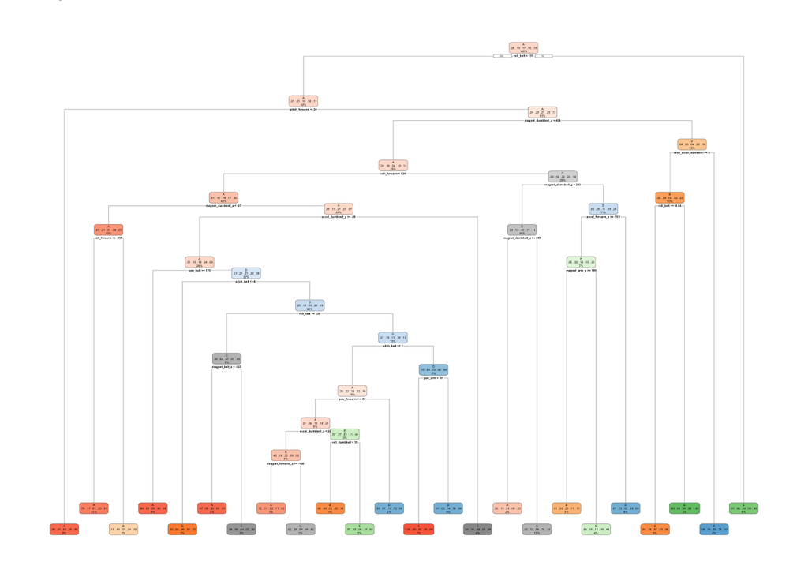

```r
library(rpart)
library(rpart.plot)
#We might get different results if we use train function from the caret package with method = rpart as compared to rpart function from rpart package. This is primarily because of different sets of default parameters for the two functions. Hence, it is always better to use the specific function for a model than using a generic train function.
mod.rpart <- rpart(classe ~ ., data = training, method = "class")
predict.rpart <- predict(mod.rpart,testing, type = "class")
rpart.plot(mod.rpart)
```

### Model 2: Random Forest

```r
library(randomForest)
mod.rf <- randomForest::randomForest(classe ~ ., data = training)
predict.rf <- predict(mod.rf, testing)
```

### Model 3: PCA Random Forest

```r
preproc <- preProcess((training[,-grep("classe", colnames(training), value = F)]), method="pca", thresh = 0.99) #threshold is set so that 99% of the variance is explained by the principal components
preproc
```

```
## Created from 14718 samples and 52 variables
##
## Pre-processing:
##   - centered (52)
##   - ignored (0)
##   - principal component signal extraction (52)
##   - scaled (52)
##
## PCA needed 37 components to capture 99 percent of the variance
```

```r
trainPC <- predict(preproc, training[,-grep("classe", colnames(training), value = F)])

mod.PCARF <- randomForest::randomForest(training$classe~., data=trainPC)

testPC <- predict(preproc, testing[,-grep("classe", colnames(training), value = F)])
predict.PCARF <- predict(mod.PCARF, testPC)
```

## Evaluation of Models

```r
results <- data.frame(matrix(nrow = 3,ncol = 2))
row.names(results) <- c("Decision Trees", "Random Forest", "PCA Followed by Random Forest")
colnames(results) <- c("Accuracy", "Out-of-sample Error (1-Accuracy)")
results[1,1] <- confusionMatrix(testing$classe,predict.rpart)$overall[1]
results[2,1] <- confusionMatrix(testing$classe,predict.rf)$overall[1]
results[3,1] <- confusionMatrix(testing$classe, predict.PCARF)$overall[1]
results$`Out-of-sample Error (1-Accuracy)` <- 1-results$Accuracy
results
```

```
##                                Accuracy Out-of-sample Error (1-Accuracy)
## Decision Trees                0.7469413                      0.253058728
## Random Forest                 0.9959217                      0.004078303
## PCA Followed by Random Forest 0.9800163                      0.019983687
```

- Thus, from the above analyses, it is clear that the second model, random forest is the most accurate model and has the least out of sample error.
- Therefore, we will use random forest model to predict the values on the final test data.

## Final Prediction

- Final prediction is based upon the random forest algorithm which has >99% accuracy

```r
predict.final <- predict(mod.rf, finalTestingData)
predict.final
```

```
##  1  2  3  4  5  6  7  8  9 10 11 12 13 14 15 16 17 18 19 20
##  B  A  B  A  A  E  D  B  A  A  B  C  B  A  E  E  A  B  B  B
## Levels: A B C D E
```